# Project II report

First enter your name and ID below. Then, answer the questions and report on your results according to the instructions. Your code needs to be submitted via a pull request to your github repo. Both the code and report will be graded.

### Name: Yehonathan Barda

### ID: 327569174

## Part A - one Ar atom in a 1D harmonic trap

**Simulation definitions:**

$$ V = \frac{1}{2} m \omega_0^2 x^2 $$

Number of particles: 1.

Initial position: x = 5 Angstrom.

Periodic boundary conditions: No.

Nsteps = 10000.

trap frequency = $\hbar \omega_0 = 50$ meV.

Temperature = 298 K.

**Questions and figures:**

1. Figure 1: Plot the acceptance ratio with respect to the maximal allowed translation step size.
2. What is the maximal step size you can use so that the acceptance ratio is 60%?
3. Figure 2: Plot the position of the particle vs. step number. Explain the observed trajectory.
4. Figure 3: Plot the potential energy vs. step number. Explain the observed behavior.
5. Figure 4: Plot the histogram of the position of the particle. Drop the first 100 data points.
6. Explain the shape of the histograms in Figure 4 in comparison to the result of Ex.1.

### Question 1

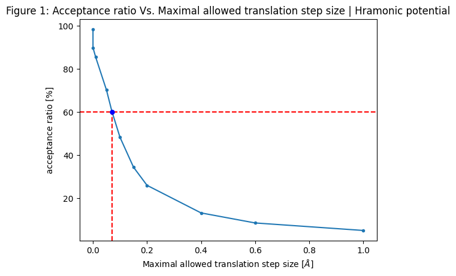

### Question 2

For the acceptance ratio to be 60% I have to use maximal step size of: $\Delta = 0.07 Å$

### Question 3

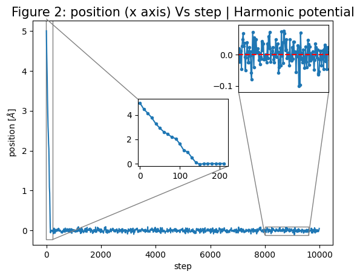

At the first ~100 steps potential energy is high, therefore steps that increase the energy are unlikely so almost only steps that reduce the potential energy (steps towards the origin) will be accepted.

At some step, the algorithm will reach a point where the possitions are distributed according to the desired Boltzmann distribution and form there and forwords all new points will be distributed accordingly and the position will oscillate around zero.

### Question 4

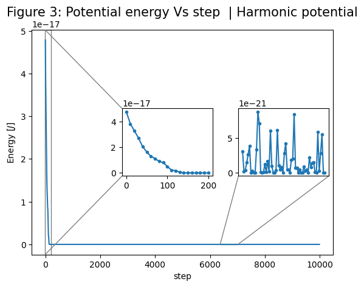

### Question 5

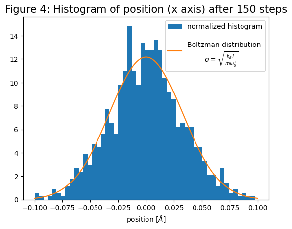

### Question 6

The shape of figure 4 is a gaussian centerd at zero. In this exercise we sampled a harmonic oscillator in the *canonical ensemble* contrary to the *micro-canonical ensemble* (Ex. 1). There for the microstate distribute according to boltzman distrabution: $$ \rho (\vec{x}, \vec{y}) \propto e^{-\beta {\mathcal{H}}(\vec{x}, \vec{y})} $$

Substitute The hamiltonian of harmonic oscillator and integrating over the momentum provides us with the distribution of possitions: $$ \rho (\vec{x}) \propto \int{ e^{-\beta \left(\frac{\vec{p}^2}{2m} + \frac{1}{2}m \omega _0 ^2 \vec{x}^2\right) } d^3p} \propto e^{- \frac{1}{2}\frac{m \omega _0 ^2}{k_B T} \vec{x}^2 } $$ Which is a gaussian centerd at $x=0$ with standard deviation $\sigma = \sqrt{\frac{k_B T}{m \omega ^2 _0}}$ as we observed in figure 4.

In exercise 1 we sampled the harmonic oscillator from the *micro-canonical ensemble* at regular intervals, so naturally the histogram has different shape.

## Part B - one Ar atom in a 1D anharmonic trap

**Simulation definitions:**

$$ V = \frac{1}{4} \lambda x^4 $$

Number of particles: 1.

Initial position: x = 0.5 Angstrom.

Periodic boundary conditions: No.

Nsteps = 10000.

Use $\lambda = 7.757 \cdot 10^{23} J m^{-4}$.

Temperature = 298 K.

**Questions and figures:**

1. Figure 1: Plot the acceptance ratio with respect to the maximal allowed translation step size.
2. What is the maximal step size you can use so that the acceptance ratio is 60%? Compare with Part A.
3. Figure 2: Plot the position of the particle vs. step number. Explain the observed trajectory.
4. Figure 3: Plot the potential energy vs. step number. Explain the observed behavior.
5. Figure 4: Plot the histogram of the position of the particle. Drop the first 100 data points. Compare with Part A.

### Question 1

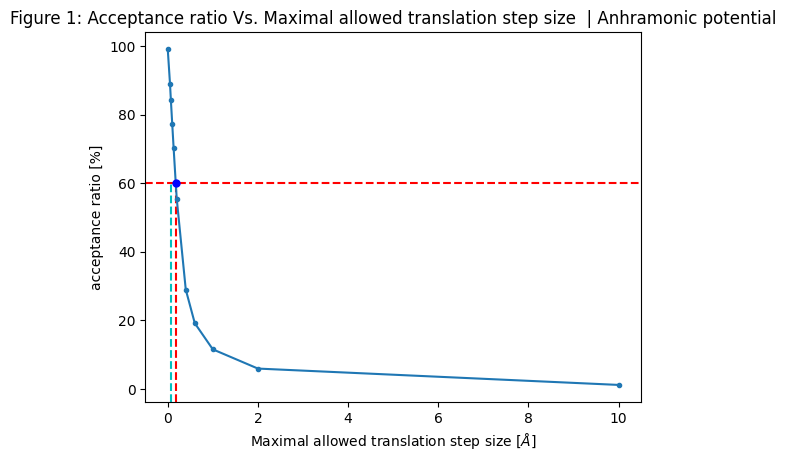

### Question 2

For the acceptance ratio to be 60% I have to use maximal step size of: $\Delta = 0.177 Å$ which is larger then part A.

### Question 3

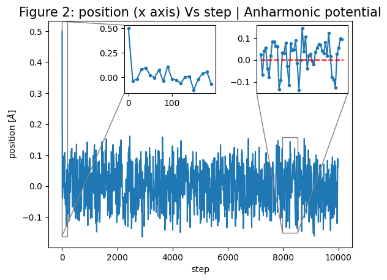

Similar to harmonic oscilltor, at the first ~100 steps potential energy is high, therefore steps that increase the energy are unlikely so almost only steps that reduce the potential energy (steps towards the origin) will be accepted.

At some step, the algorithm will reach a point where the possitions are distributed according to the desired Boltzmann distribution and form there and forwords all new points will be distributed accordingly and the position will oscillate around zero.

### Question 4

[figure not shown]

### Question 5

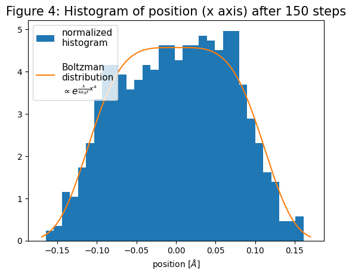

In figure 4 the histogram is wide "gaussian-like" centerd at zero. In this exercise we sampled an anharmonic oscillator in the *canonical ensemble*. There for the microstate distribute according to boltzman distrabution: $$ \rho (\vec{x}, \vec{y}) \propto e^{-\beta {\mathcal{H}}(\vec{x}, \vec{y})} $$

Substitute The hamiltonian of anharmonic oscillator and integrating over the momentum provides us with the distribution of possitions: $$ \rho (\vec{x}) \propto \int{ e^{-\beta \left(\frac{\vec{p}^2}{2m} + \frac{1}{4} \lambda \vec{x}^4\right) } d^3p} \propto e^{- \frac{1}{4}\frac{\lambda}{k_B T} \vec{x}^4 } $$

And after normalization: $$ \rho (\vec{x}) = \frac{2 \sqrt{2}}{\Gamma{\left(\frac{1}{4}\right)}} \sqrt[4]{\frac{k_B T}{\lambda}} e^{- \frac{1}{4}\frac{\lambda}{k_B T} \vec{x}^4 } $$

Which is a simular to the gaussian form part A and fit the observed histogram in figure 4.

In part A we simulated a harmonic oscillator $\left( \sim x^2 \right)$ and hear we simulated an anharmonic oscillator $\left( \sim x^4 \right)$ and we get roughly the same results with the change of the power of $x$ form 2 to 4.

## Part C - 256 Argon particles with PBC

**Simulation definitions:**

Number of particles: 256.

Potential: Lennard Jones with $\varepsilon = 1.656778224E-21 $ J and $\sigma = 3.4$ Angstrom.

Initial positions: Use the provided Ar_init_super.xyz. Note, it is given in Angstrom.

Periodic boundary conditions: Yes, L=22.6 Angstrom.

Nsteps = 10000.

Print xyz and therodynamics every: 100 steps.

Temperature = 298 K.

**Questions and figures:**

1. Figure 1: Plot the acceptance ratio maximal step size. Determine the step size leading to 60% acceptance.
2. Figure 2: Using that step size, plot the potential energy vs. step number. Explain the observed behavior.
3. Figure 3: Plot the average histogram of the distances between all the particles* in the range [0,15] Angstrom.
4. Repeat the simulation when you sample for T = 40 K.
5. Repeat the simulation with L=113 Angstrom, Scale the initial coordinates by a factor of 5 in each dimension, use T=298 K.
6. Compare the three histograms. What do you observe? Explain the difference.

*You can either implement it yourself or load the final xyz file of the simulation into [VMD](https://www.ks.uiuc.edu/Research/vmd/) and use their analysis tool for obtaining the pair radial distribution function. It is similar to the histogram, but normalized differently. You can read more about it in the Book by Allen and Tildesley from the syllabus.

### Question 1

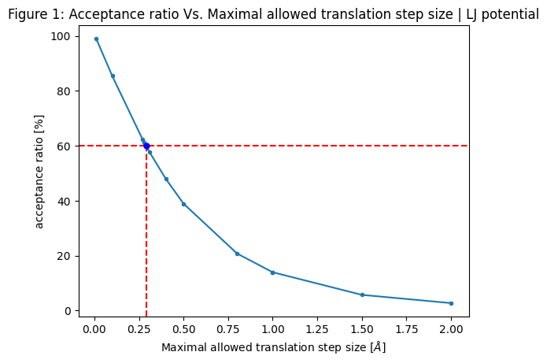

For the acceptance ratio to be 60% I have to use maximal step size of: $\Delta = 0.28 Å$

### Question 2

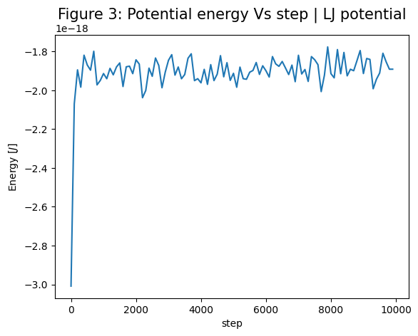

The potential energy of the initial state is low, therfore steps that increse the potential energy are more likly to be accepted.

At some step, the algorithm will reach a point where the possitions are distributed according to the desired Boltzmann distribution and form there and forwords all new points will be distributed accordingly and the potential energy will oscillate around some average value.

### Question 3

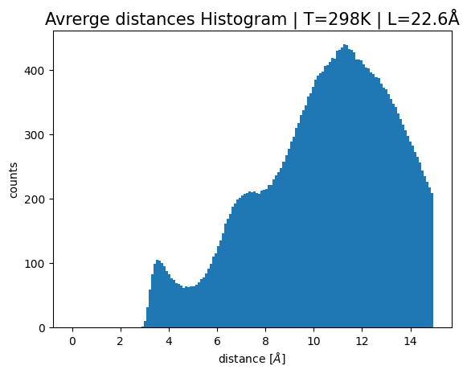

### Question 4

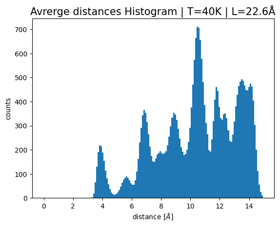

### Question 5

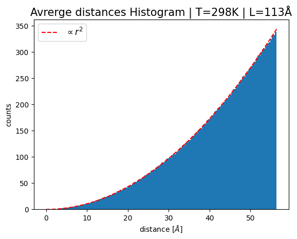

### Question 6

The histograms in this part are the same as those from Ex.1.

- For $T=298K$ and $L=22.6 Å$: the histogram corresponds to liquid state. the atoms free to flow but the kinetic energy isn't sufficient to completely overcome the atraction forces. therefore there are 3 more common distances with a large variance (wide peaks)
- For $T=40$ and $L=22.6 Å$: the histogram corresponds to solid state. the atoms vibrate around a fixed point. therefore there are distinct distances between atoms with a small variance (narrow peaks)
- For $T=298$ and $L=113 Å$: the histogram corresponds to gase state. the atom are free to move with negligible interaction between them. there for the radial distribution is proportional to $ r^2 $ (as explained in Ex.1).

More detailed explanation in Ex.1.

As we already noticed, the results in this part (MC in the *canonicl ensamble*) are identiacl to the results in Ex.1 (MD in the *micro-canonical ensamble*). this is due to the equivalence for systems with a large amount of particles, We can conclude that 256 is in fact a large enough.

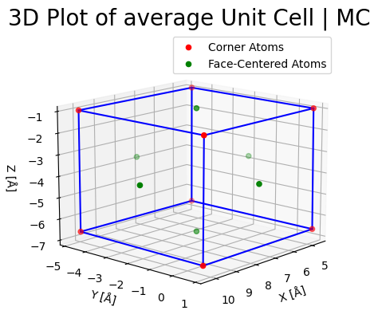

```
The Lattice constant (length of the sides of the unit cell) is: 5.64 ± 0.05 Å
```